# Gaps in the Evidence

Marcello Di Bello (mdibello@asu.edu) and Rafal Urbaniak

15th Orange Beach Epistemology Workshop - May 23-24, 2023

# 0 The Question

Disputes about matters of fact in trial proceedings should be adjudicated in light of the evidence presented by the litigants. But, should the fact that some evidence was *not* presented also—at least in some circumstances—guide trial decisions? If so, how? This is the problem of gaps in the evidence or the problem of missing evidence.

By “missing evidence” I shall usually mean the known fact that some evidence is missing whose content is unknown.

: dismissive responses to the problem of missing evidence (1); the legal framework (2); prejudice and reliability as two competing criteria (3); epistemic and policy considerations in formualating remedies for missing evidence (4); reliability and fortuitousness as key guiding criteria (5).

# 1 Dismissive Responses

Some might claim that the problem of missing evidence is not a difficult problem and can be easily addressed: either (1) missing evidence is irrelevant and thus should play no role in trial decisions, or (2) if it is relevant, it is just like any other evidence so it poses no peculiar problem. Let’s consider each of these in turn.

1. *Missing evidence is not relevant evidence*

Missing evidence could be in favor or against either party. The two possibilities cancel each other out. So missing evidence is irrelevant:

> [I]f the evidence is missing it cannot be known which way it points. It appears equally possible that the missing evidence would confirm the current factual conclusion as contradict it. The competing possibilities cancel each other out. There is no warrant for the assumption that the missing evidence will point one way rather than the other.

> Hamer, D. (2012). Probability, Anti-resilience, and the Weight of Expectation. *Law, Probability and Risk*, 11(2-3), 135–158, 139.

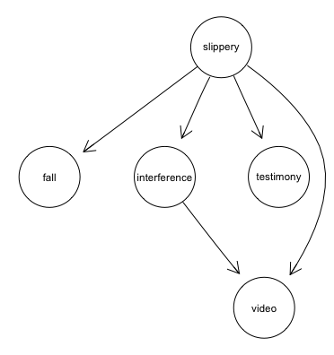

DAG of the Target case.

The missing recording would have null value only if it were just as likely that Target would attempt to remove the recording when the floor was slippery as when it was not.

2. *Missing evidence is just any other kind of evidence*

Let $E_p$ the evidence presented at trial and let $E_m$ describe known facts about missing evidence, for example, that the video recording is missing. The overall body of evidence should consist of $E_p \wedge E_m$. In making decisions about a hypothesis $H$, we should consider $Pr(H \vert E_p \wedge E_m)$ rather than simply $Pr(H \vert E_p)$.

Kaye, D. H. (1986). Do we Need a Calculus of Weight to Understand Proof Beyond a Reasonable Doubt? *Boston University Law Review*, 66, 657–672.

If missing evidence is relevant evidence, $Pr(H \vert E_p \wedge E_m) \neq Pr(H \vert E_p)$. But can this be the whole story? Likely not. To see why not, let’s take a look at the legal framework for handling missing evidence.

# 2 Legal Framework

The legal framework for handling missing evidence is three-tiered:

The case law in the United States often follows this framework. See e.g. Decker v. Target Corp., No. 1:16-cv-00171-JNP-BCW (D. Utah Oct. 10, 2018) or Howard v. United States, No. 18-CF-15, (District of Columbia Court of Appeals, Nov. 19, 2020).

> First, ask about the *prejudicial effects* of the missing evidence. Could the missing evidence have made a difference to the verdict?

> A related question concerns what we might call *would-be-relevance*: would the missing evidence if presented be relevant? This question can be subsumed under the question of prejudice.

> Second, examine the *circumstances* that caused the evidence to be missing. Was it an accident or misconduct? Did one of the parties have a duty to preserve the missing evidence?

> Third, devise a *remedy* (such as an adverse jury instruction) to be granted to the litigant disadvantaged by the missing evidence.

# 3 Prejudice (or Reliability?)

To better understand the notion of prejudice, below is an example from the case law about missing evidence not regarded as prejudicial:

> Defendant is charged with illegal possession of firearm. The police legally searched the defendant’s vehicle and found a firearm. The defendant had no permit. The police searches the rest of the car and finds a backpack, but does not retain all the items in the backpack: keys, pieces of paper, trash. The defense complains that the evidence is incomplete: information about the contents of the backpack is missing. In particular, defense argues that the keys could be exculpatory evidence: if they did not belong to the defendant, the backpack did not either, and neither did the firearm.

> Howard v. United States, No. 18-CF-15, (District of Columbia Court of Appeals, Nov. 19, 2020).

The Court reasoned that the inferences to be drawn from the missing evidence—for example, the missing keys—were ‘wholly speculative’ and thus the missing evidence was not prejudicial.

This conclusion seems sensible. It would be odd if any missing piece of information—given a broad enough interpretation—could alter the balance of the evidence and thus be prejudicial.

But, is prejudice the right criterion to focus on? Even if adding the missing evidence could have changed the verdict (prejudice), this addition could have also lowered the reliability of the decision-making process. In a slogan, the claim “More Evidence, Fewer Errors” is not true in general. For consider this example:

Define reliability as the weighted average of the sensitivity and specificity of a binary decision-making process (say, a gain in specificity can be valued twice as much as a gain in sensitivity).

This is a challenge to the principle of total evidence. See, for example, Good, I. J. (1967). On the principle of total evidence. *British Journal for the Philosophy of Science*, 17(4), 319–321.

This example is liberally inspired by Lee Johnson v. Jeff Premo (2021 Oregon App. Ct.), Marion County Circuit Court08C11553 - A159635.

> Reliable match evidence links the defendant to the crime scene in a murder case. There is no evidence, however, about the defendant’s whereabouts before or after the crime nor about who else visited the crime scene. Compare this case with one in which the same evidence is presented but—in addition—a neighbor testifies that another person visited the victim’s house before the defendant did. This additional evidence, though relevant, has a low probative value compared to the match evidence: the neighbor is an elderly man whose memory has proven unreliable in other circumstances. This testimony, if added, could change the verdict (prejudice) but would also make the decision process less reliabile than a decision based on just match evidence.

> Suppose match evidence is 99% reliable, so $Pr(M^+ | G)=Pr(M^- \vert I)=.99$. Testimonial evidence in the case, instead, is only 51% reliable, so $Pr(T^+ | G)=Pr(T^- \vert I)=.51$. Decisions based on $M^{+/-}$ will be 99% reliable. Instead, decisions based on $M^{+/-}\wedge T^{+/-}$ will be less reliable. Sensitivity will be much worse than 99%, that is, $P(M^+ \wedge I^+ \vert G)=.99\times 0.51\approx .5$. The assumption here is that a conviction is issued only when both items of evidence are incriminating, $M^+\wedge T^+$. Specificity will be only slightly better than 99%, that is, $P(M^- \wedge I^- \vert I) + P(M^+ \wedge I^- \vert I) + P(M^- \wedge I^+ \vert G) \approx .995$.

Some might object that evidence is routinely presented at trial that could be misleading or could lower the reliability of the decision-making process. So reliability cannot be the key criterion for deciding whether further evidence should be taken into account.

But there is an important difference. When evidence is *actually* presented in trial proceedings, it is subject to adversarial scrutiny and cross-examination. This process is intended to detect sources of unreliability in the evidence. Instead, missing evidence cannot be subject to adversarial testing since its content is unknown. This difference is well-understood in the case law:

> A primary function of jury instructions, as well as the rules of procedure and evidence, is to confine the jury’s attention to firsthand testimony … which may be probed on cross-examination, thereby excluding conjecture … The risk is always present that the jury will give undue weight to the presumed content of testimony not presented, and insufficient weight to that which was presented.

> Thomas v. United States, 447 A.2d 52, 58 (D.C. 1982).

This approach seems to align with legal practice. For example, the missing evidence in the case would have clearly enhanced the reliability of the decision-making process. We can conjecture, then, that the law prefers cases in which (it is relatively clear that) the missing evidence, if added, would improve reliability.

# 4 Circumstances and Remedies: Epistemology or Policy?

We now turn to the question of how remedies for missing evidence should be devised. Two approaches can be identified:

: remedies should only follow a conscientiousness assessment of the evidence. That some evidence was not presented can itself be information (evidence) for drawing inferences together with other evidence that was presented. This approach is internal to the logic of evidence evaluation. So the remedy here only consists in adjusting the probability of a hypothesis given missing evidence, that is, $Pr(H \vert E_p)\neq Pr(H \vert E_p \wedge E_m)$.

The epistemic response aligns with the dismissive response (2) in 1 according to which “Missing evidence is just any other kind of evidence”.

: Gaps in the evidence can be the result of objectionable out-of-court behavior that must be sanctioned.

# 5 Two Guiding Questions